# nb_07_Salifort_Motors_project_Decision_Tree_Model

# Review Results

```python
model1 = model_dt1
model2 = model_dt2

model_name1 = "model_dt1"
model_name2 = "model_dt2"

model_best_model1 = model_dt1_best_model
model_best_model2 = model_dt2_best_model
```

## Dataset comparison - Decision Tree

There is little difference in performance between the two datasets.

- `ALLFeat` = complete feature engineered dataset
- `NoDept` = dataset with dummy encoded dept removed

## Model performance

The AUC score for the DecisionTree is [0.978] This is a significant improvement over Logistical Regression which came in at ~0.886 but had a low predicted to leave score.

F1, Precision, Recall and Accuracy are also within acceptable ranges

Predictions have also improved significantly, with predicted to leave now at ~0.9x.

```python
display_results()
```

|  | Model | Precision | Recall | F1 | Accuracy | AUC | Predict Leave | Predict Stay |
| --- | --- | --- | --- | --- | --- | --- | --- | --- |
| 5 | dt1 - ALLFeat - test | 0.9784 | 0.9785 | 0.9785 | 0.9785 | 0.9791 | 0.9359 | 0.9871 |
| 8 | dt2 - NOdept - test | 0.9784 | 0.9785 | 0.9785 | 0.9785 | 0.9791 | 0.9359 | 0.9871 |
| 6 | dt1 - ALLFeat - train | 0.9784 | 0.9786 | 0.9784 | 0.9786 | 0.9789 | 0.9352 | 0.9872 |
| 9 | dt2 - NOdept - train | 0.9784 | 0.9786 | 0.9784 | 0.9786 | 0.9789 | 0.9352 | 0.9872 |
| 7 | dt2 - NOdept - GS train | 0.9506 | 0.9135 | 0.9317 | 0.9774 | 0.9737 | NaN | NaN |
| 4 | dt1 - ALLFeat - GS train | 0.9506 | 0.9135 | 0.9317 | 0.9774 | 0.9737 | NaN | NaN |
| 1 | lr1 - ALLFeat - train | 0.7960 | 0.8266 | 0.8041 | 0.8266 | 0.8923 | 0.3284 | 0.9005 |
| 3 | lr2 - NOdept - train | 0.7930 | 0.8248 | 0.8015 | 0.8248 | 0.8919 | 0.3180 | 0.8995 |
| 0 | lr1 - ALLFeat - test | 0.7943 | 0.8216 | 0.8031 | 0.8216 | 0.8819 | 0.3413 | 0.8969 |
| 2 | lr2 - NOdept - test | 0.7952 | 0.8227 | 0.8039 | 0.8227 | 0.8819 | 0.3426 | 0.8975 |

### Confusion Matrix Heatmap - `model_dt1`

```
<function matplotlib.pyplot.show(close=None, block=None)>
```

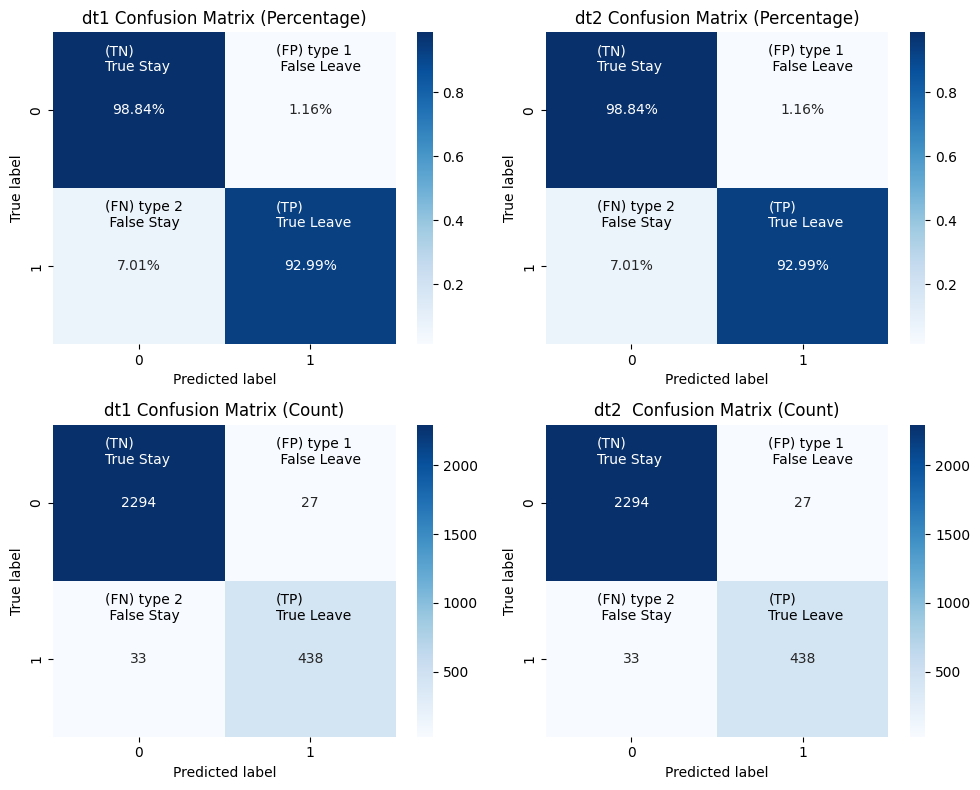

```python
# Prepare confusion matrices for LR1 test
cm_test1 = metrics.confusion_matrix(y_test, y_pred_test)  # Use the optimized model
#cm_test1_percent = cm_test1 / cm_test1.sum() * 100

# Prepare confusion matrices for LR1 train
cm_test2 = metrics.confusion_matrix(y_test2, y_pred_test2)  # Use the optimized model
#cm_test2_percent = cm_test2 / cm_test2.sum() * 100

#cm = confusion_matrix(y_test, y_pred_test, labels=model_lr1.classes_)

# Plot confusion matrix
#disp = ConfusionMatrixDisplay(confusion_matrix=cm,
#                             display_labels=model_lr1.classes_)
#disp.plot(values_format='');

fig, ax = plt.subplots(2, 2, figsize=(10,8))

# Calculate percentages for TEST
sum_by_true_class = np.sum(cm_test1, axis=1)
percentage_matrix = cm_test1 / sum_by_true_class[:, np.newaxis]
model_name = "dt1"
# Create a figure and plot the percentage confusion matrix as a heatmap

sns.heatmap(percentage_matrix, annot=True, fmt=".2%", cmap="Blues", ax = ax[0,0]) #, xticklabels=model_lr1.classes_, yticklabels=model_lr1.classes_)
ax[0,0].set_title('{} Confusion Matrix (Percentage)'.format(model_name))
ax[0,0].set_ylabel('True label')
ax[0,0].set_xlabel('Predicted label')
ax[0,0].text(0.3, 0.25, '(TN)\nTrue Stay', color='white')
ax[0,0].text(1.3, 0.25, '(FP) type 1\n False Leave', color='black')
ax[0,0].text(0.3, 1.25, '(FN) type 2\n False Stay', color='black')
ax[0,0].text(1.3, 1.25, '(TP)\nTrue Leave', color='white')



# Create a figure and plot the COUNT confusion matrix as a heatmap for TEST
sns.heatmap(cm_test1, annot=True, fmt=".0f", cmap="Blues", ax = ax[1,0])#, xticklabels=class_labels, yticklabels=class_labels)
ax[1,0].set_title('{} Confusion Matrix (Count)'.format(model_name))
ax[1,0].set_ylabel('True label')
ax[1,0].set_xlabel('Predicted label')
ax[1,0].text(0.3, 0.25, '(TN)\nTrue Stay', color='white')
ax[1,0].text(1.3, 0.25, '(FP) type 1\n False Leave', color='black')
ax[1,0].text(0.3, 1.25, '(FN) type 2\n False Stay', color='black')
ax[1,0].text(1.3, 1.25, '(TP)\nTrue Leave', color='black')



# Calculate percentages for TRAIN
sum_by_true_class = np.sum(cm_test2, axis=1)
percentage_matrix = cm_test2 / sum_by_true_class[:, np.newaxis]
model_name = "dt2"

sns.heatmap(percentage_matrix, annot=True, fmt=".2%", cmap="Blues", ax = ax[0,1])#, xticklabels=class_labels, yticklabels=class_labels)
ax[0,1].set_title('{} Confusion Matrix (Percentage)'.format(model_name))
ax[0,1].set_ylabel('True label')
ax[0,1].set_xlabel('Predicted label')
ax[0,1].text(0.3, 0.25, '(TN)\nTrue Stay', color='white')
ax[0,1].text(1.3, 0.25, '(FP) type 1\n False Leave', color='black')
ax[0,1].text(0.3, 1.25, '(FN) type 2\n False Stay', color='black')
ax[0,1].text(1.3, 1.25, '(TP)\nTrue Leave', color='white')


# Create a figure and plot the COUNT confusion matrix as a heatmap for TRAIN
sns.heatmap(cm_test2, annot=True, fmt=".0f", cmap="Blues", ax = ax[1,1])#, xticklabels=class_labels, yticklabels=class_labels)
ax[1,1].set_title('{}  Confusion Matrix (Count)'.format(model_name))
ax[1,1].set_ylabel('True label')
ax[1,1].set_xlabel('Predicted label')
ax[1,1].text(0.3, 0.25, '(TN)\nTrue Stay', color='white')
ax[1,1].text(1.3, 0.25, '(FP) type 1\n False Leave', color='black')
ax[1,1].text(0.3, 1.25, '(FN) type 2\n False Stay', color='black')
ax[1,1].text(1.3, 1.25, '(TP)\nTrue Leave', color='black')


plt.tight_layout()
plt.show
```

### Feature Importance

```
             Feature  Importance model_xg1 - AllFeat  Importance model_xg2 - NoDept
0       satisfaction                          0.5898                         0.5898
1             tenure                          0.1542                         0.1542
2          last_eval                          0.1475                         0.1475
3     number_project                          0.1086                         0.1086
4     dept_technical                          0.0000                            NaN
5             salary                          0.0000                         0.0000
6          promotion                          0.0000                         0.0000
7         overworked                          0.0000                         0.0000
8    dept_accounting                          0.0000                            NaN
9            dept_hr                          0.0000                            NaN
10        dept_sales                          0.0000                            NaN
11        dept_randd                          0.0000                            NaN
12  dept_product_mng                          0.0000                            NaN
13    dept_marketing                          0.0000                            NaN
14   dept_management                          0.0000                            NaN
15           dept_it                          0.0000                            NaN
16      dept_support                          0.0000                            NaN
```

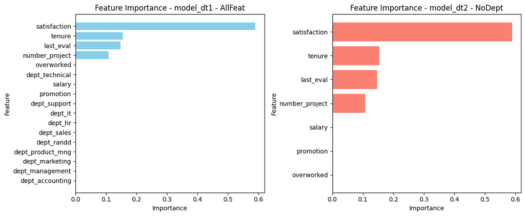

```python
#tree2_importances = pd.DataFrame(tree2.best_estimator_.feature_importances_, columns=X.columns)
# Get feature importances (Gini importance)
feature_importance1 = model_best_model1.feature_importances_
feature_importance2 = model_best_model2.feature_importances_

# Get the names of the features
feature_names1 = X.columns  # Replace with your feature names
feature_names2 = X2.columns  # Replace with your feature names

# Create a DataFrame to store feature names and their Gini importance
feature_importance_df1 = pd.DataFrame({'Feature': feature_names1, 'Importance': feature_importance1})
feature_importance_df2 = pd.DataFrame({'Feature': feature_names2, 'Importance': feature_importance2})


feature_importance_df1.sort_values(by='Importance', ascending=False,axis=0, inplace=True)
feature_importance_df2.sort_values(by='Importance', ascending=False,axis=0, inplace=True)


merged_df = pd.merge(feature_importance_df1, feature_importance_df2, on='Feature', how='left', suffixes = (' model_xg1 - AllFeat', ' model_xg2 - NoDept'))

# Print the merged DataFrame
print(merged_df)

feature_importance_df1.sort_values(by='Importance', ascending=True,axis=0, inplace=True)
feature_importance_df2.sort_values(by='Importance', ascending=True,axis=0, inplace=True)

# Plot side-by-side bar plots
plt.figure(figsize=(12, 5))

plt.subplot(1, 2, 1)
plt.barh(feature_importance_df1['Feature'], feature_importance_df1['Importance'], color='skyblue')
plt.title('Feature Importance - {} - AllFeat'.format(model_name1))
plt.xlabel('Importance')
plt.ylabel('Feature')

plt.subplot(1, 2, 2)
plt.barh(feature_importance_df2['Feature'], feature_importance_df2['Importance'], color='salmon')
plt.title('Feature Importance - {} - NoDept'.format(model_name2))
plt.xlabel('Importance')
plt.ylabel('Feature')

plt.tight_layout()
plt.show()
```

## Precision / Recall Curve

```python
## Prepare predictions and calculate model scores

y_prob1 = model1.predict_proba(X_test)[:, 1]
y_prob2 = model2.predict_proba(X_test2)[:, 1]

precision1, recall1, _ = precision_recall_curve(y_test, y_prob1)
precision2, recall2, _ = precision_recall_curve(y_test2, y_prob2)

# Compute area under the curve (AUC)
auc_score1 = auc(recall1, precision1)
auc_score2 = auc(recall2, precision2)
```

```python
print(type(precision1))
print(type(recall1))
print(type(auc_score1))
```

```
<class 'numpy.ndarray'>
<class 'numpy.ndarray'>
<class 'numpy.float64'>
```

```python
# read in previous plot data

# Logistic Regression

variables = [['auc_score1', 'model_lr1'],
             ['auc_score2', 'model_lr2'],
             ['roc_auc1', 'model_lr1'],
             ['roc_auc2', 'model_lr2']
             ]

arrays = [['precision1','model_lr1'],
         ['recall1', 'model_lr1'],
         ['precision2','model_lr2'],
         ['recall2', 'model_lr2'],
         ['fpr1', 'model_lr1'],
         ['tpr1', 'model_lr1'],
         ['fpr2', 'model_lr2'],
         ['tpr2', 'model_lr2'],
        ]


loaded_plot_vars = {}
loaded_plot_arrays = {}

for var_name, model in variables:
    #print(var_name, model)
    #var = globals()[var_name]
    with open(f'99-documentation-project/08-plot_data/{model}-{var_name}.csv', 'r') as file:
        var = f'{model}-{var_name}'
        #print(var)
        loaded_plot_vars[var] = json.load(file)



for array_name, model in arrays:
    #print(array_name, model)
    #var = globals()[var_name]
    filepath = f'99-documentation-project/08-plot_data/{model}-{array_name}.csv'
    array = f'{model}-{array_name}'
    loaded_plot_arrays[array] = pd.read_csv(filepath)


#print(loaded_plot_arrays)
#var = loaded_plot_vars.get('model_lr1-roc_auc1')
#print(var)

#array= loaded_plot_arrays.get('model_dt2-precision2')

#lr1_fpr1 = loaded_plot_arrays.get('model_lr1-fpr1')

#va = lr1_fpr1.values()

#print(type(lr1_fpr1))
#print(lr1_fpr1)

# Retrieve arrays and variable from previous model


lr1_precision1 = loaded_plot_arrays.get('model_lr1-precision1') # retrieve fpr1 array from model1 = AllFeat
lr1_recall1 = loaded_plot_arrays.get('model_lr1-recall1') # retrieve fpr1 array from model1 = AllFeat
lr1_auc_score1 = loaded_plot_vars.get('model_lr1-auc_score1') # retrieve auc score from model1 = AllFeat

lr2_precision2 = loaded_plot_arrays.get('model_lr2-precision2') # retrieve fpr1 array from model1 = AllFeat
lr2_recall2 = loaded_plot_arrays.get('model_lr2-recall2') # retrieve fpr1 array from model1 = AllFeat
lr2_auc_score2 = loaded_plot_vars.get('model_lr2-auc_score2') # retrieve auc score from model1 = AllFeat

lr1_fpr1 = loaded_plot_arrays.get('model_lr1-fpr1') # retrieve fpr1 array from model1 = AllFeat
lr1_tpr1 = loaded_plot_arrays.get('model_lr1-tpr1') # retrieve tpr1 array from model1 = AllFeat
lr1_roc_auc1 = loaded_plot_vars.get('model_lr1-roc_auc1') # retrieve auc score from model1 = AllFeat
lr1_model_name1 = arrays[0][1] # Retrieve model_name1

lr2_fpr2 = loaded_plot_arrays.get('model_lr2-fpr2') # retrieve fpr1 array from model2 = AllFeat
lr2_tpr2 = loaded_plot_arrays.get('model_lr2-tpr2') # retrieve tpr1 array from model2 = AllFeat
lr2_roc_auc2 = loaded_plot_vars.get('model_lr2-roc_auc2') # retrieve auc score from model1 = AllFeat
lr2_model_name2 = arrays[3][1] # Retrieve model_name2

#print(lr1_precision1)
#print(lr1_recall1)
```

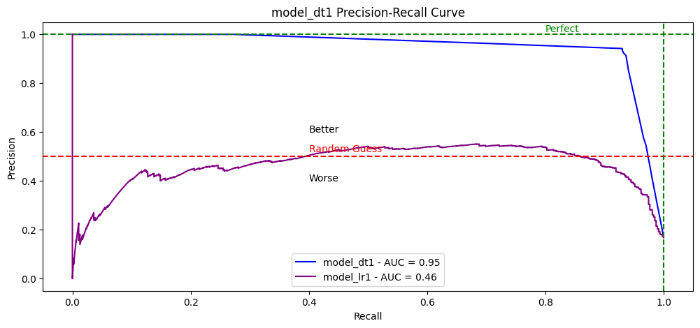

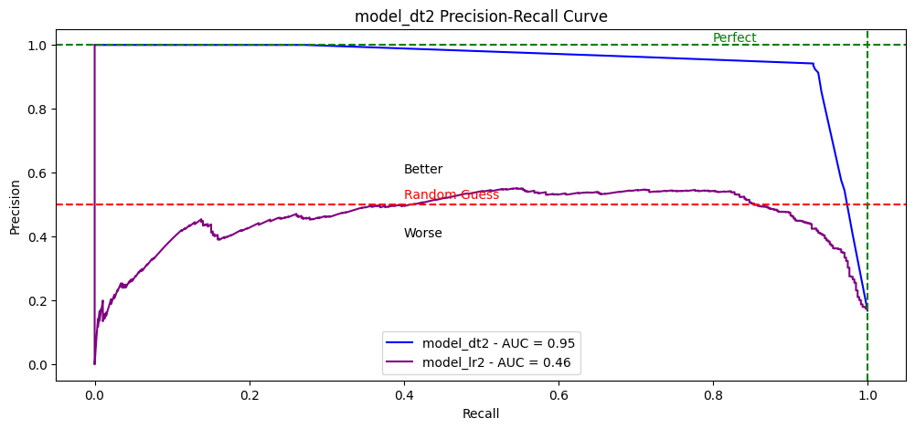

```python
# Plot the Precision / Recall curve




#plt.subplot(1, 2, 1)
plt.figure(figsize=(12, 5))
plt.plot(recall1, precision1, color='blue', label=f'{model_name1} - AUC = {auc_score1:.2f}')
plt.plot(lr1_recall1, lr1_precision1, color='purple', label=f'{lr1_model_name1} - AUC = {lr1_auc_score1:.2f}')
plt.xlabel('Recall')
plt.ylabel('Precision')
plt.title('{} Precision-Recall Curve'.format(model_name1))
plt.legend(loc='best')
plt.axhline(y=0.5, color='red', linestyle='--', label='Random Guess')
plt.axhline(y=1, color='green', linestyle='--', label='Perfect')
plt.axvline(x=1, color='green', linestyle='--', label='Perfect')
plt.text(0.4, 0.52, 'Random Guess', color='red')
plt.text(0.4, 0.6, 'Better', color='black')
plt.text(0.4, 0.4, 'Worse', color='black')
plt.text(0.8, 1.01, 'Perfect', color='green')
plt.show()

#plt.subplot(1, 2, 2)
plt.figure(figsize=(12, 5))
plt.plot(recall2, precision2, color='blue', label=f'{model_name2} - AUC = {auc_score2:.2f}')
plt.plot(lr2_recall2, lr2_precision2, color='purple', label=f'{lr2_model_name2} - AUC = {lr2_auc_score2:.2f}')
plt.xlabel('Recall')
plt.ylabel('Precision')
plt.title('{} Precision-Recall Curve'.format(model_name2))
plt.legend(loc='best')
plt.axhline(y=0.5, color='red', linestyle='--', label='Random Guess')
plt.axhline(y=1, color='green', linestyle='--', label='Perfect')
plt.axvline(x=1, color='green', linestyle='--', label='Perfect')
plt.text(0.4, 0.52, 'Random Guess', color='red')
plt.text(0.4, 0.6, 'Better', color='black')
plt.text(0.4, 0.4, 'Worse', color='black')
plt.text(0.8, 1.01, 'Perfect', color='green')

#plt.tight_layout()
plt.show()
```